# Regression and Factor Analysis: TIMSS data

### Transformations

Let’s recode variables to numbers:

```r
bullying[, 1:11] <- lapply(bullying[, 1:11], as.factor)
```

We should transform all variables into a factor type, because all variables have only 4 levels. Moreover, these variables are of ordinal type of measurement, so we cannot treat them as numeric.

```r
sapply(bullying, class)
```

```
##  ASBG11A  ASBG11B  ASBG11C  ASBG11D  ASBG11E  ASBG11F  ASBG11G  ASBG11H
## "factor" "factor" "factor" "factor" "factor" "factor" "factor" "factor"
##  ASBG11I  ASBG11J  ASBG11K
## "factor" "factor" "factor"
```

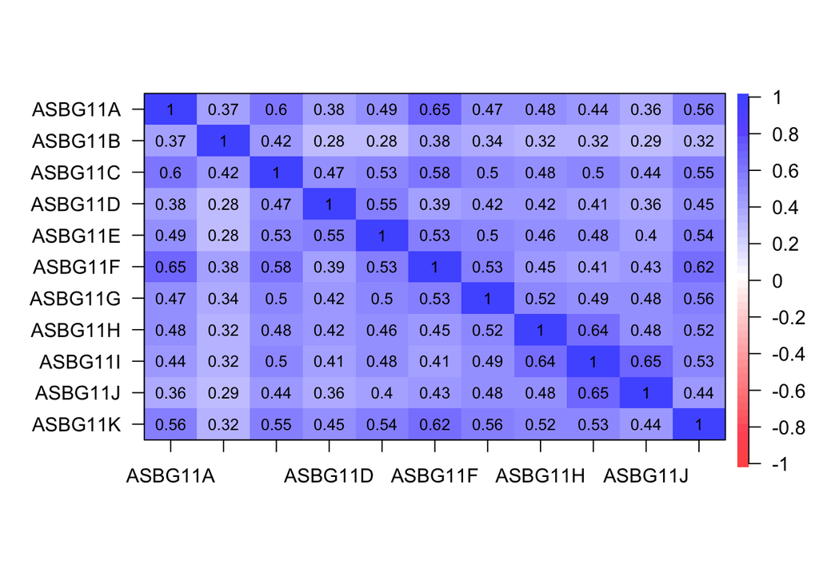

```r
bullying <- as.data.frame(bullying)
library(psych)
library(polycor) #polychoric correlations
library(corrplot)
bul_cor <- hetcor(bullying) #heterogeneous correlations
cor.plot(bul_cor$correlations)
```

- All variables are positively correlated
- Some variables have large correlations between each other (from 0.6 to 0.65)
- Most variable have medium correlations between each other (from 0.4 to 0.58)
- However, there are also small correlations (from 0.28 to 0.38)
- ASBG11B (LEFT OUT OF GAMES) has small correlations with all variables, except for ASBG11C (SPREADING LIES ABOUT ME) (0.42)

### Parallel Analysis screen plot

- Helps determine the number of factors

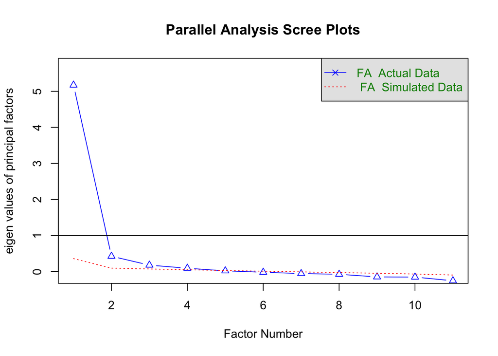

```
## Parallel analysis suggests that the number of factors =  4  and the number of components =  NA
```

```r
fa.parallel(bul_cor$correlations, n.obs=2032, fa="fa", n.iter=100)
```

- We should look where red dotted line is crossed with triangles’ line. The number of factors should be determined by the number of triangles before this intersection. Also, we can look at black horizontal line (eigenvalues).
- As for red dotted line, there are 3 triangles before the intersection and the 4th triangle is crossed by red dotted line. According to this approach, we should use 4 factors. Also, in system message there is a hint for us: “Parallel analysis suggests that the number of factors = 4”
- But, according to eigenvalues, we should extract 1 factor.
- Thus, let’s start from the biggest number - 4 factors.

## EFA

### Four factors

- by default, rotation is enabled

```r
library(GPArotation)
fa(bul_cor$correlations, 4, cor = "mixed")
```

```
## Factor Analysis using method =  minres
## Call: fa(r = bul_cor$correlations, nfactors = 4, cor = "mixed")
## Standardized loadings (pattern matrix) based upon correlation matrix
##           MR1   MR2   MR3   MR4   h2   u2 com
## ASBG11A  0.80  0.01 -0.03 -0.01 0.61 0.39 1.0
## ASBG11B  0.52  0.08  0.00 -0.20 0.29 0.71 1.4
## ASBG11C  0.67  0.08  0.15 -0.16 0.62 0.38 1.2
## ASBG11D -0.04 -0.01  0.84 -0.03 0.65 0.35 1.0
## ASBG11E  0.18  0.09  0.50  0.16 0.56 0.44 1.6
## ASBG11F  0.78 -0.03  0.00  0.17 0.70 0.30 1.1
## ASBG11G  0.30  0.28  0.17  0.15 0.50 0.50 3.1
## ASBG11H  0.18  0.51  0.11  0.04 0.53 0.47 1.4
## ASBG11I -0.05  0.98 -0.02 -0.02 0.88 0.12 1.0
## ASBG11J  0.09  0.62  0.02  0.02 0.50 0.50 1.0
## ASBG11K  0.39  0.20  0.17  0.25 0.62 0.38 2.8
##
##                        MR1  MR2  MR3  MR4
## SS loadings           2.72 2.10 1.36 0.28
## Proportion Var        0.25 0.19 0.12 0.03
## Cumulative Var        0.25 0.44 0.56 0.59
## Proportion Explained  0.42 0.32 0.21 0.04
## Cumulative Proportion 0.42 0.75 0.96 1.00
##
##  With factor correlations of
##      MR1  MR2  MR3  MR4
## MR1 1.00 0.62 0.66 0.37
## MR2 0.62 1.00 0.60 0.15
## MR3 0.66 0.60 1.00 0.17
## MR4 0.37 0.15 0.17 1.00
##
## Mean item complexity =  1.5
## Test of the hypothesis that 4 factors are sufficient.
##
## The degrees of freedom for the null model are  55  and the objective function was  5.33
## The degrees of freedom for the model are 17  and the objective function was  0.07
##
## The root mean square of the residuals (RMSR) is  0.01
## The df corrected root mean square of the residuals is  0.03
##
## Fit based upon off diagonal values = 1
## Measures of factor score adequacy
##                                                    MR1  MR2  MR3   MR4
## Correlation of (regression) scores with factors   0.94 0.95 0.89  0.63
## Multiple R square of scores with factors          0.88 0.91 0.79  0.40
## Minimum correlation of possible factor scores     0.76 0.82 0.58 -0.20
```

However, I think it is better to run the EFA with 3 factors, and then look at factor loadings and other parameters to decide on deleting problematic manifest variables.

### Three factors

```r
library(GPArotation)
fa <- fa(bul_cor$correlations, 3, cor = "mixed", fm="ml",  scores=T)
fa
```

```
## Factor Analysis using method =  ml
## Call: fa(r = bul_cor$correlations, nfactors = 3, scores = T, fm = "ml",
##     cor = "mixed")
## Standardized loadings (pattern matrix) based upon correlation matrix
##           ML2   ML1   ML3   h2    u2 com
## ASBG11A  0.78  0.03 -0.04 0.60 0.400 1.0
## ASBG11B  0.38  0.09  0.05 0.23 0.771 1.1
## ASBG11C  0.56  0.11  0.16 0.56 0.437 1.3
## ASBG11D -0.03 -0.01  0.84 0.66 0.344 1.0
## ASBG11E  0.32  0.08  0.44 0.55 0.454 1.9
## ASBG11F  0.90 -0.07 -0.03 0.71 0.295 1.0
## ASBG11G  0.44  0.18  0.17 0.48 0.523 1.6
## ASBG11H  0.23  0.48  0.12 0.52 0.475 1.6
## ASBG11I -0.04  0.99 -0.02 0.92 0.078 1.0
## ASBG11J  0.15  0.58  0.03 0.49 0.512 1.1
## ASBG11K  0.56  0.16  0.13 0.58 0.418 1.3
##
##                        ML2  ML1  ML3
## SS loadings           3.03 1.97 1.29
## Proportion Var        0.28 0.18 0.12
## Cumulative Var        0.28 0.45 0.57
## Proportion Explained  0.48 0.31 0.20
## Cumulative Proportion 0.48 0.80 1.00
##
##  With factor correlations of
##      ML2  ML1  ML3
## ML2 1.00 0.60 0.64
## ML1 0.60 1.00 0.57
## ML3 0.64 0.57 1.00
##
## Mean item complexity =  1.3
## Test of the hypothesis that 3 factors are sufficient.
##
## The degrees of freedom for the null model are  55  and the objective function was  5.33
## The degrees of freedom for the model are 25  and the objective function was  0.1
##
## The root mean square of the residuals (RMSR) is  0.02
## The df corrected root mean square of the residuals is  0.03
##
## Fit based upon off diagonal values = 1
## Measures of factor score adequacy
##                                                    ML2  ML1  ML3
## Correlation of (regression) scores with factors   0.94 0.97 0.88
## Multiple R square of scores with factors          0.88 0.94 0.78
## Minimum correlation of possible factor scores     0.77 0.87 0.56
```